# Case Study

Group 48

## Is there a relationship between gender / age with the number of cases?

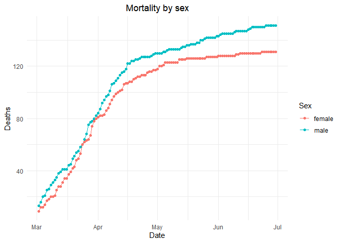

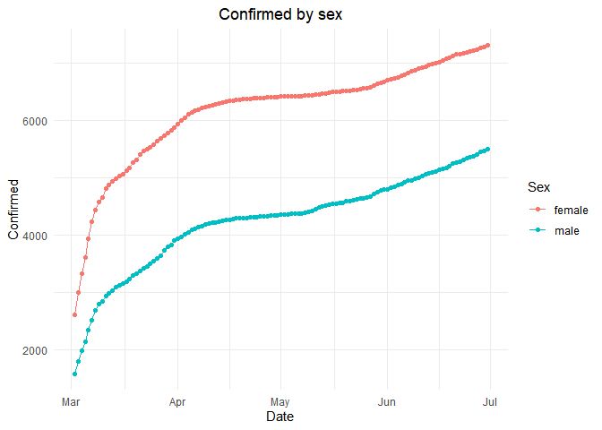

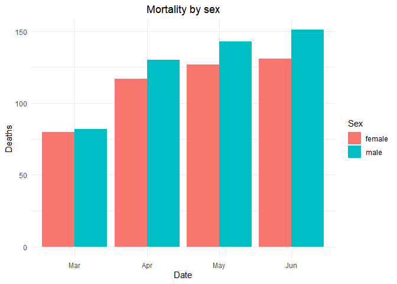

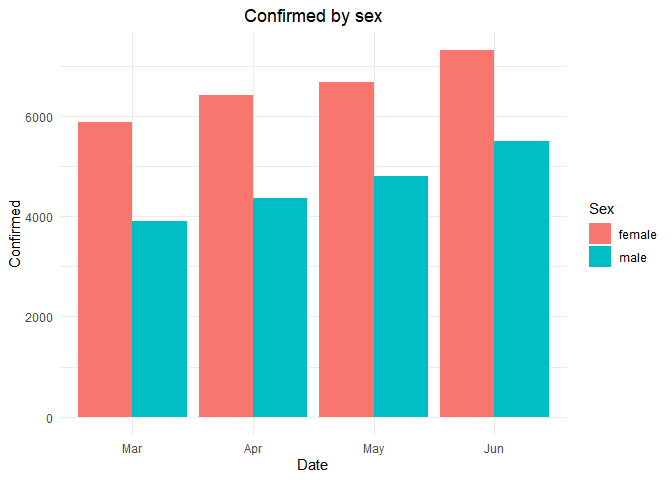

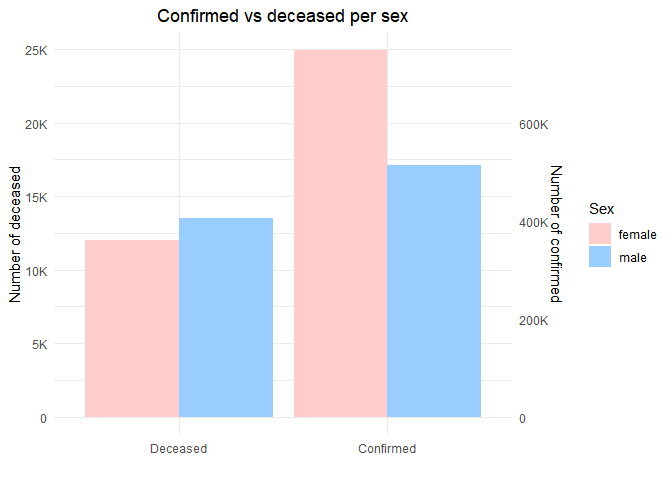

- to support our claims, we made another graph to compare those values
- from this graph the relations are clearly seen; why men are more affected has not yet been scientifically proven, but we have proven our hypothesis
- mortality rate for male: approx. 2.6%
- mortality rate for female: approx. 1.6%

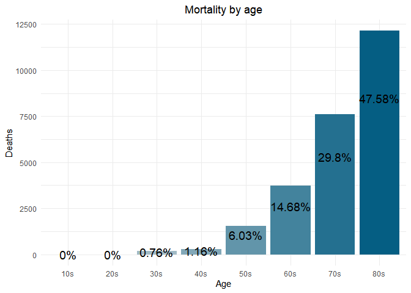

- mortality increases in proportion to the age span, almost 50% of deceased are in their 80s
- this could be explained by severe deficiency in certain classes of immune cells that fight off infections and decline over time

## What role different types of policies play on the number of cases?

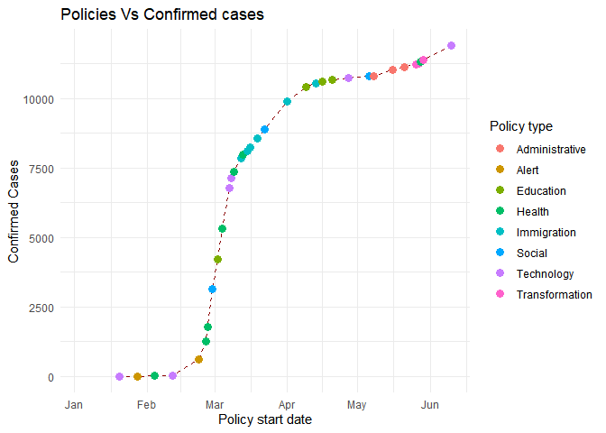

- government kept on implementing and iterating on the policies in the different sectors
- and was able to flatten the curve by June 2020

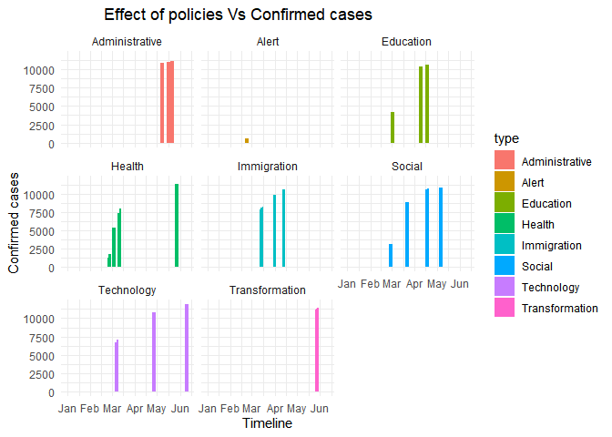

- the policies of the type : Health, Social and Immigration proved promising as after certain policies implementation the rate of increase in the cases was reduced
- reforms in the education and technological policies may have also played a role decreasing the rate
- administrative policies were implemented fairly late

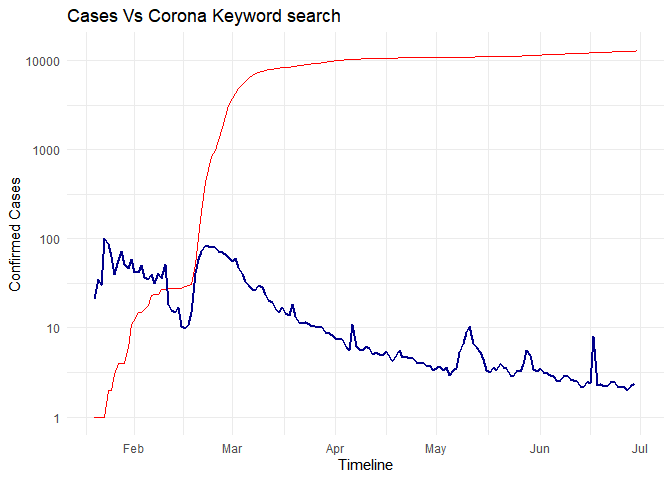

## Is weather influencing the number of people infected?

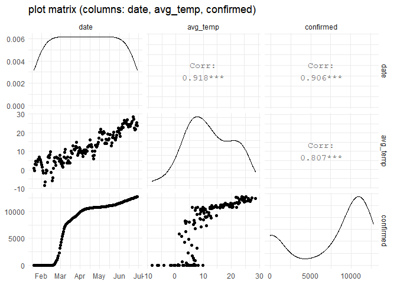

- from the Plotting matrix it was obvious that a relationship between temperature and confirmed cases existed

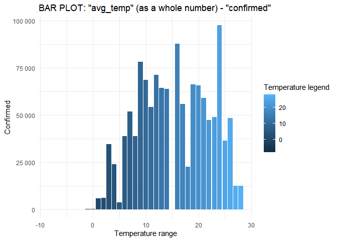

## The higher the floating population, the more infections seem to occur?

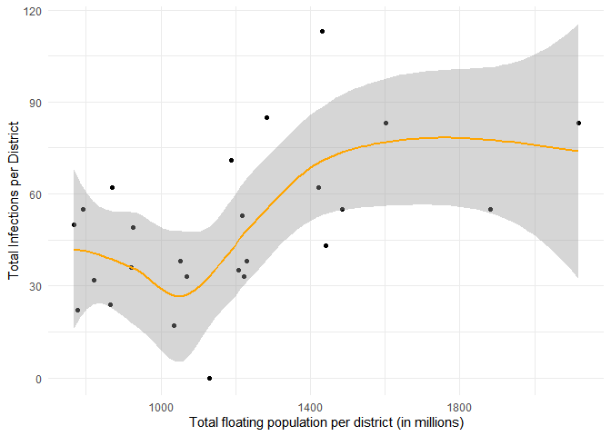

- comparison of total infected patients per city (district) in Seoul from PatientInfo with total number of floating population from SeoulFloating
- cor = 0.5 indicates that other factors influence the infection count too (population count of city, inner population movement (non-floating movement),…)